# IODS course project

Benjamin Roberts

# About the project

This course teaches students to use the statistical programming software R to prepare and analyze data.

### Github Repository

https://github.com/blrobert/IODS-project

# Regression and model validation

This week I have learned to setup, perform and analyze simple linear regression with multiple variables.

- Describe your work and results clearly.
- Assume the reader has an introductory course level understanding of writing and reading R code as well as statistical methods
- Assume the reader has no previous knowledge of your data or the more advanced methods you are using

```r
lrn14<-read.csv("learning2014.csv",row.names=1)
str(lrn14)
```

```
## 'data.frame':    166 obs. of  7 variables:
##  $ gender  : Factor w/ 2 levels "F","M": 1 2 1 2 2 1 2 1 2 1 ...
##  $ Age     : int  53 55 49 53 49 38 50 37 37 42 ...
##  $ attitude: num  3.7 3.1 2.5 3.5 3.7 3.8 3.5 2.9 3.8 2.1 ...
##  $ deep    : num  3.58 2.92 3.5 3.5 3.67 ...
##  $ stra    : num  3.38 2.75 3.62 3.12 3.62 ...
##  $ surf    : num  2.58 3.17 2.25 2.25 2.83 ...
##  $ Points  : int  25 12 24 10 22 21 21 31 24 26 ...
```

```r
dim(lrn14)
```

```
## [1] 166   7
```

This dataset includes 166 rows and 7 columns (variables). The variables are Age, Gender, (exam) Points, Attitude, Surface Learning, Strategic Learning and Deep Learning.

install.packages(“GGally”) install.packages(“ggplot2”)

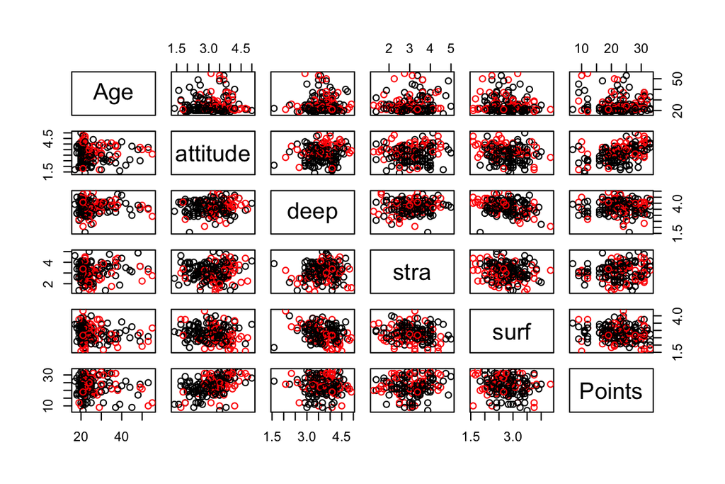

```r
library(ggplot2)
library(GGally)
pairs(lrn14[-1],col=lrn14$gender)
```

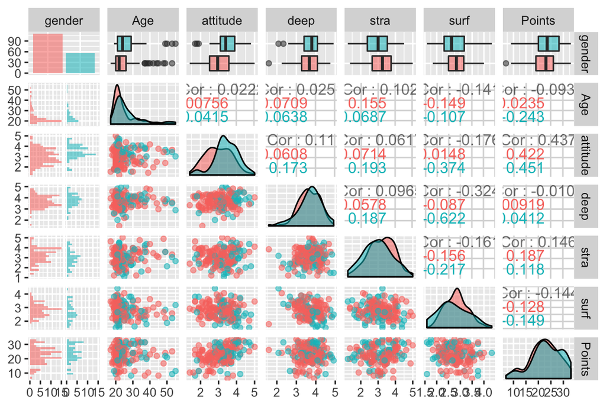

```r
ggpairs(lrn14, mapping=aes(col=gender, alpha=0.3), lower=list(combo=wrap("facethist",bins=20)))
```

```r
summary(lrn14)
```

```
##  gender       Age           attitude          deep            stra
##  F:110   Min.   :17.00   Min.   :1.400   Min.   :1.583   Min.   :1.250
##  M: 56   1st Qu.:21.00   1st Qu.:2.600   1st Qu.:3.333   1st Qu.:2.625
##          Median :22.00   Median :3.200   Median :3.667   Median :3.188
##          Mean   :25.51   Mean   :3.143   Mean   :3.680   Mean   :3.121
##          3rd Qu.:27.00   3rd Qu.:3.700   3rd Qu.:4.083   3rd Qu.:3.625
##          Max.   :55.00   Max.   :5.000   Max.   :4.917   Max.   :5.000
##       surf           Points
##  Min.   :1.583   Min.   : 7.00
##  1st Qu.:2.417   1st Qu.:19.00
##  Median :2.833   Median :23.00
##  Mean   :2.787   Mean   :22.72
##  3rd Qu.:3.167   3rd Qu.:27.75
##  Max.   :4.333   Max.   :33.00
```

```r
my_model<-lm(Points~attitude+deep+surf, data=lrn14)
summary(my_model)
```

```
##
## Call:
## lm(formula = Points ~ attitude + deep + surf, data = lrn14)
##
## Residuals:
##      Min       1Q   Median       3Q      Max
## -16.9168  -3.1487   0.3667   3.8326  11.3519
##
## Coefficients:
##             Estimate Std. Error t value Pr(>|t|)
## (Intercept)  18.3551     4.7124   3.895 0.000143 ***
## attitude      3.4661     0.5766   6.011 1.18e-08 ***
## deep         -0.9485     0.7903  -1.200 0.231815
## surf         -1.0911     0.8360  -1.305 0.193669
## ---
## Signif. codes:  0 '***' 0.001 '**' 0.01 '*' 0.05 '.' 0.1 ' ' 1
##
## Residual standard error: 5.313 on 162 degrees of freedom
## Multiple R-squared:  0.2024, Adjusted R-squared:  0.1876
## F-statistic:  13.7 on 3 and 162 DF,  p-value: 5.217e-08
```

```r
my_model2<-lm(Points~attitude,data=lrn14)
```

```r
summary(my_model2)
```

```
##
## Call:
## lm(formula = Points ~ attitude, data = lrn14)
##
## Residuals:
##      Min       1Q   Median       3Q      Max
## -16.9763  -3.2119   0.4339   4.1534  10.6645
##
## Coefficients:
##             Estimate Std. Error t value Pr(>|t|)
## (Intercept)  11.6372     1.8303   6.358 1.95e-09 ***
## attitude      3.5255     0.5674   6.214 4.12e-09 ***
## ---
## Signif. codes:  0 '***' 0.001 '**' 0.01 '*' 0.05 '.' 0.1 ' ' 1
##
## Residual standard error: 5.32 on 164 degrees of freedom
## Multiple R-squared:  0.1906, Adjusted R-squared:  0.1856
## F-statistic: 38.61 on 1 and 164 DF,  p-value: 4.119e-09
```

R-squared is a measure of how close the true observations are to the fitted line, and thus a determination of how well the model explains the variation of observations around the data’s mean. It tells you how much of the variance in the target variable can be explained by the explanatory variables. R-squared values range from 0 to 1, with 0 indicating that the model explains none of the variation, and 1 indicating that the explanatory variables used explain all of the variation in the target variable. My model has an R-squared of 0.2024, meaning that it has relatively low explanatory power and there are substantial differences between the fitted lines for each explanatory variable and the actual observations.

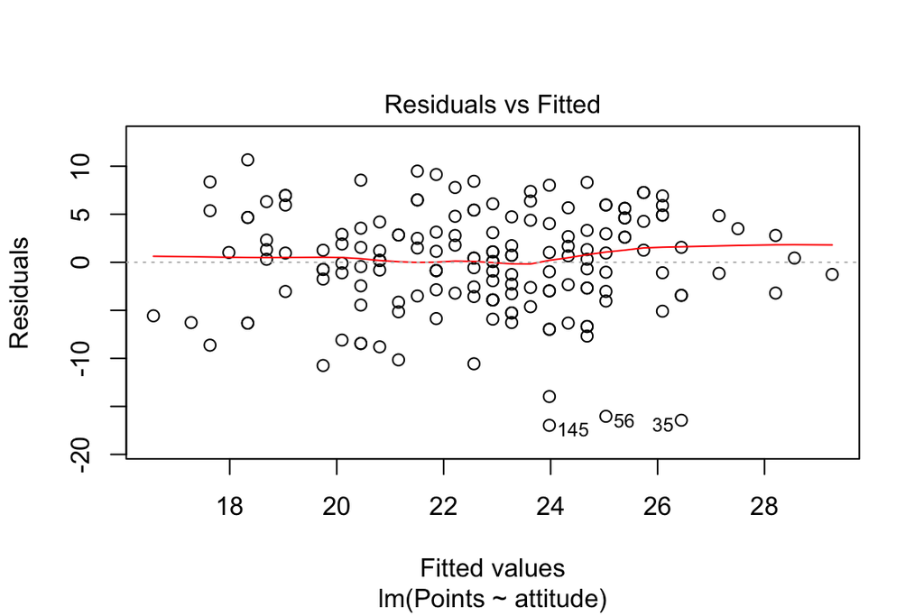

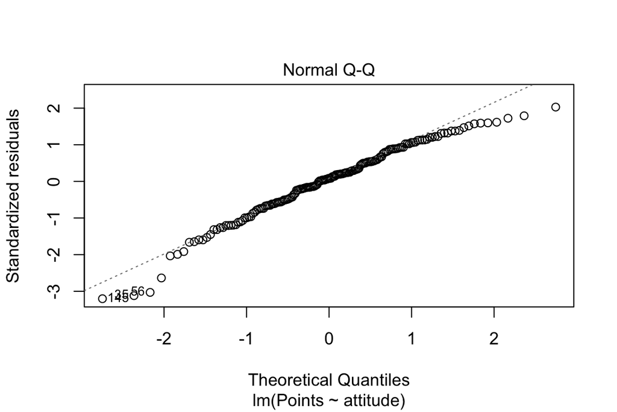

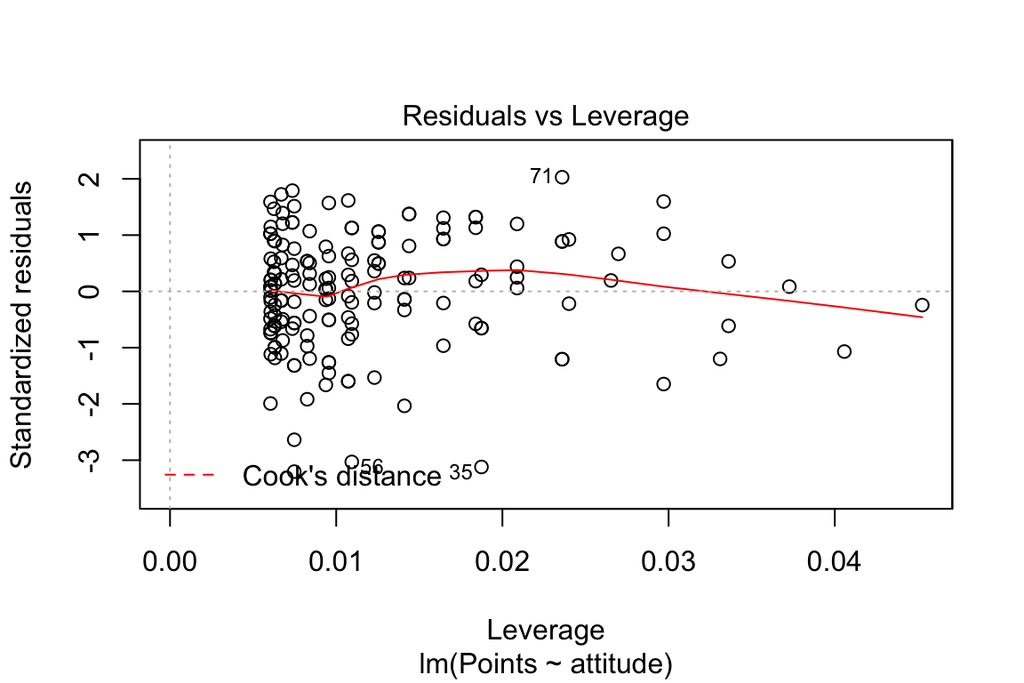

```r
plot(my_model2, which=c(1:2,5))
```

The assumptions of the linear regression model are that the errors are normally distributed, the errors are not correlated and the errors have constant varaiance (and, as such, the size of an error does not depend on the explanatory variables). For my model, the normality assumption is reasonable, because the points are for the most part tightly fitted to the line in the Q-Q Plot and there are no extreme outliers. The constant variance assumption is also reasonable, because there is a random spread of points with no clear pattern in the graph comparing residuals and model predictions. The Residuals vs. Leverage plot indicates that the data has regular leverage, because there is no significant outlier (the leverage values range from 0 to 0.04) that has a disproportionate effect on the model.

# Logistic Regression

Introduction to logistic regression and cross validation

```r
alc <- read.csv("alc.csv",row.names=1)
```

```r
colnames(alc)
```

```
##  [1] "school"     "sex"        "age"        "address"    "famsize"
##  [6] "Pstatus"    "Medu"       "Fedu"       "Mjob"       "Fjob"
## [11] "reason"     "nursery"    "internet"   "guardian"   "traveltime"
## [16] "studytime"  "failures"   "schoolsup"  "famsup"     "paid"
## [21] "activities" "higher"     "romantic"   "famrel"     "freetime"
## [26] "goout"      "Dalc"       "Walc"       "health"     "absences"
## [31] "G1"         "G2"         "G3"         "alc_use"    "high_use"
```

```r
dim(alc)
```

```
## [1] 382  35
```

The data inclues 382 rows (students) and 35 variables/columns. Each variable indicates attributes and grade information about students in either math or Portuguese language courses.

I will test Pstatus, studytime, failures and higher in relation to high/low alcohol consumption. For those students with Pstatus apart (false), there will be a higher probability of high alcohol consumption. For those students with higher weekly study times, there will be a lower probability of high aclohol consumption. For those students with a higher number of failures, there will be a higher probability of high alcohol consumption. For those students who want to pursue higher education, there will be a lower probablility of high aclohol consumption.

install.packages(“GGally”) install.packages(“ggplot2”)

```r
library(ggplot2)
library(GGally)
```

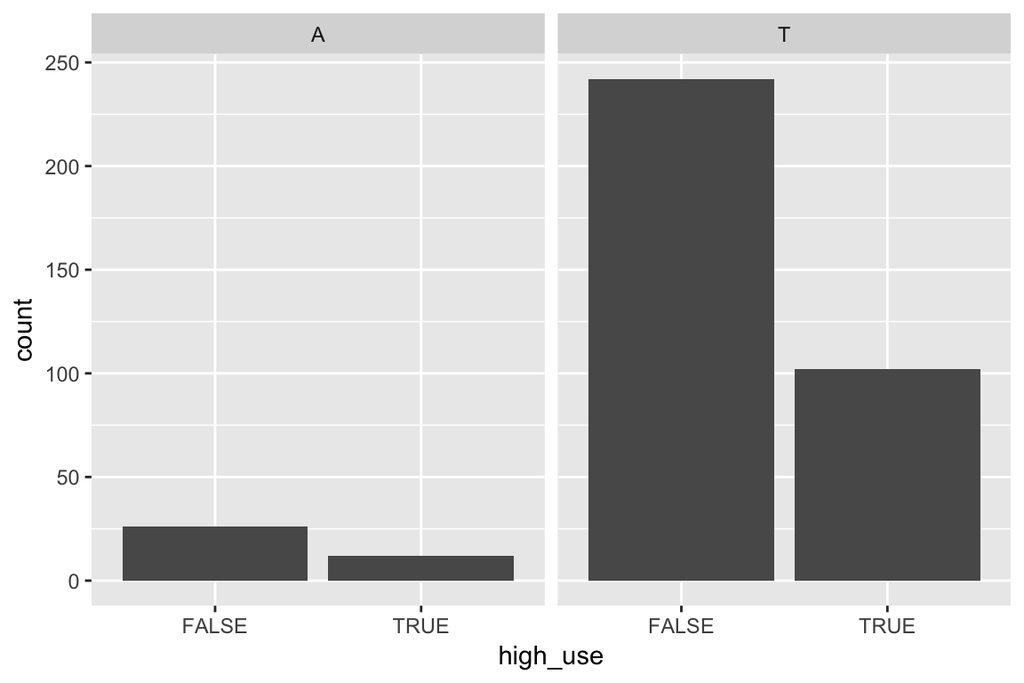

```r
bar<-ggplot(data=alc, aes(x=high_use))
bar+facet_wrap("Pstatus")+geom_bar()
```

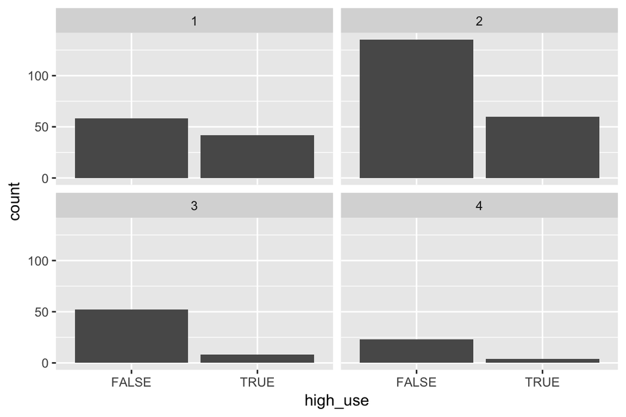

```r
bar+facet_wrap("studytime")+geom_bar()
```

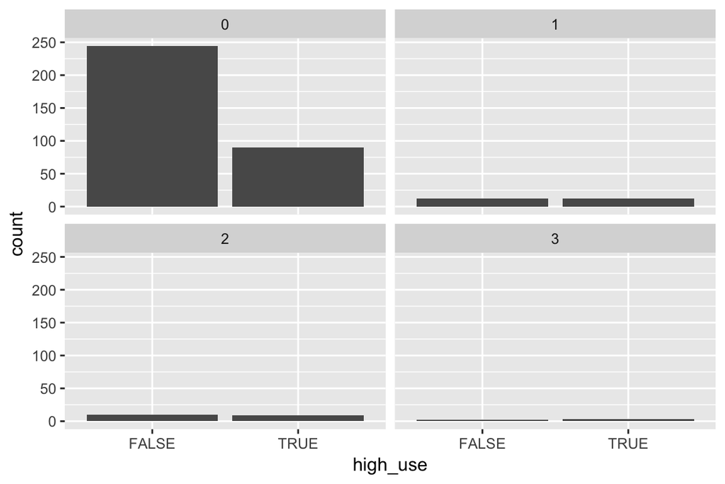

```r
bar+facet_wrap("failures")+geom_bar()
```

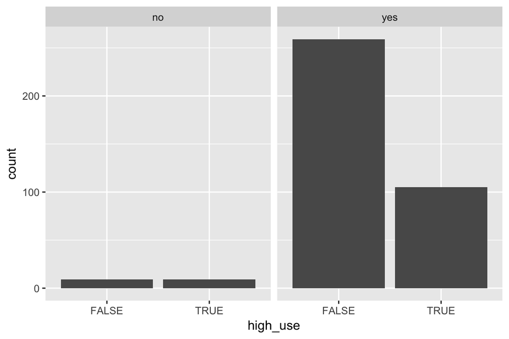

```r
bar+facet_wrap("higher")+geom_bar()
```

```r
table(high_use=alc$high_use, Pstatus=alc$Pstatus)
```

```
##         Pstatus
## high_use   A   T
##    FALSE  26 242
##    TRUE   12 102
```

```r
table(high_use=alc$high_use, studytime=alc$studytime)
```

```
##         studytime
## high_use   1   2   3   4
##    FALSE  58 135  52  23
##    TRUE   42  60   8   4
```

```r
table(high_use=alc$high_use, failures=alc$failures)
```

```
##         failures
## high_use   0   1   2   3
##    FALSE 244  12  10   2
##    TRUE   90  12   9   3
```

```r
table(high_use=alc$high_use, higher=alc$higher)
```

```
##         higher
## high_use  no yes
##    FALSE   9 259
##    TRUE    9 105
```

Based on the bar graphs and cross-tabulations, my hypotheses generally seem to be appropriate. For students whose parents live together, a higher proportion have low alcohol consumption compared with students whose parents are separated. Generally, the more students study the more likely they are to have low alcohol consumption. For students who plan to pursue higher education, a higher proportion have low alcohol consumption compared to students who don’t plan to pursue higher education. In terms of failures, however, there is a less clear relationship with alcohol consumption.

```r
model<-glm(high_use~Pstatus+studytime+failures+higher, data=alc, family="binomial")
summary(model)
```

```
##
## Call:
## glm(formula = high_use ~ Pstatus + studytime + failures + higher,
##     family = "binomial", data = alc)
##
## Deviance Residuals:
##     Min       1Q   Median       3Q      Max
## -1.5570  -0.7981  -0.7981   1.3000   2.0759
##
## Coefficients:
##             Estimate Std. Error z value Pr(>|z|)
## (Intercept)  0.41983    0.68428   0.614 0.539520
## PstatusT    -0.08093    0.37705  -0.215 0.830043
## studytime   -0.52540    0.15683  -3.350 0.000808 ***
## failures     0.34848    0.19764   1.763 0.077866 .
## higheryes   -0.26871    0.53569  -0.502 0.615936
## ---
## Signif. codes:  0 '***' 0.001 '**' 0.01 '*' 0.05 '.' 0.1 ' ' 1
##
## (Dispersion parameter for binomial family taken to be 1)
##
##     Null deviance: 465.68  on 381  degrees of freedom
## Residual deviance: 443.89  on 377  degrees of freedom
## AIC: 453.89
##
## Number of Fisher Scoring iterations: 4
```

```r
coef(model)
```

```
## (Intercept)    PstatusT   studytime    failures   higheryes
##  0.41983005 -0.08093225 -0.52540334  0.34848048 -0.26871220
```

install.packages(“tidyr”)

```r
library(tidyr)
OR<-coef(model)%>%exp
CI<-exp(confint(model))
cbind(OR,CI)
```

```
##                    OR     2.5 %    97.5 %
## (Intercept) 1.5217029 0.3876426 5.7868685
## PstatusT    0.9222562 0.4488646 1.9917762
## studytime   0.5913168 0.4308370 0.7978098
## failures    1.4169129 0.9625861 2.1018616
## higheryes   0.7643632 0.2675755 2.2483346
```

Overall, the relationships posited in my hypothesis were correct, but only study time exhibited a statistically significant relationship with alcohol consumption in the regression model.

```r
model2<-glm(high_use~studytime, data=alc, family="binomial")
summary(model2)
```

```
##
## Call:
## glm(formula = high_use ~ studytime, family = "binomial", data = alc)
##
## Deviance Residuals:
##     Min       1Q   Median       3Q      Max
## -1.0603  -0.8314  -0.8314   1.2993   2.1010
##
## Coefficients:
##             Estimate Std. Error z value Pr(>|z|)
## (Intercept)   0.3209     0.3076   1.043    0.297
## studytime    -0.6029     0.1530  -3.941  8.1e-05 ***
## ---
## Signif. codes:  0 '***' 0.001 '**' 0.01 '*' 0.05 '.' 0.1 ' ' 1
##
## (Dispersion parameter for binomial family taken to be 1)
##
##     Null deviance: 465.68  on 381  degrees of freedom
## Residual deviance: 448.31  on 380  degrees of freedom
## AIC: 452.31
##
## Number of Fisher Scoring iterations: 4
```

```r
library(dplyr)
probabilities<-predict(model2, type="response")
alc<-mutate(alc, probability=probabilities)
alc<-mutate(alc, prediction=probability>0.5)
table(high_use=alc$high_use, prediction=alc$prediction)
```

```
##         prediction
## high_use FALSE
##    FALSE   268
##    TRUE    114
```

```r
select(alc, studytime, high_use, probability, prediction) %>% head(20)
```

```
##    studytime high_use probability prediction
## 1          2    FALSE   0.2921823      FALSE
## 2          2    FALSE   0.2921823      FALSE
## 3          2     TRUE   0.2921823      FALSE
## 4          3    FALSE   0.1842725      FALSE
## 5          2    FALSE   0.2921823      FALSE
## 6          2    FALSE   0.2921823      FALSE
## 7          2    FALSE   0.2921823      FALSE
## 8          2    FALSE   0.2921823      FALSE
## 9          2    FALSE   0.2921823      FALSE
## 10         2    FALSE   0.2921823      FALSE
## 11         2    FALSE   0.2921823      FALSE
## 12         3    FALSE   0.1842725      FALSE
## 13         1    FALSE   0.4299752      FALSE
## 14         2    FALSE   0.2921823      FALSE
## 15         3    FALSE   0.1842725      FALSE
## 16         1    FALSE   0.4299752      FALSE
## 17         3    FALSE   0.1842725      FALSE
## 18         2    FALSE   0.2921823      FALSE
## 19         1     TRUE   0.4299752      FALSE
## 20         1    FALSE   0.4299752      FALSE
```

Interestingly, using the model with only study time as an explanatory variable, there are no predicted probabilities above .5 and thus no predictions of true (high alcohol consumption).

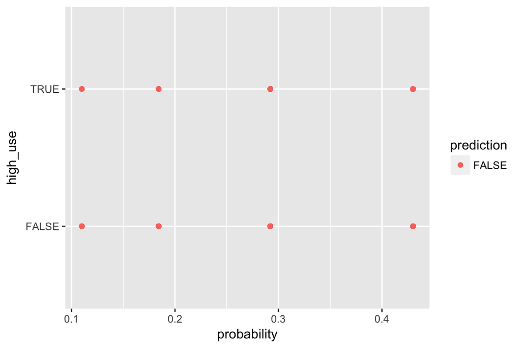

```r
library(ggplot2)
g<-ggplot(alc, aes(x=probability, y=high_use, col=prediction))
g+geom_point()
```

```r
loss_func<-function(class,prob){
  n_wrong<-abs(class-prob)>0.5
  mean(n_wrong)
}

loss_func(class=alc$high_use, prob=alc$probability)
```

```
## [1] 0.2984293
```

The training error is approximately .3, meaning that 30 percent of students are inaccurately classified in terms of their alcohol consumption (high/low). Simply guessing without a strategy gives you a 50 percent chance of being correct in a binary situation such as this, and guessing with some intuition/strategy most likely gives you an even higher chance of being correct. Thus, the performance of the model is perceivably not that much different from a simple guessing strategy.

install.packages(“boot”)

```r
library(boot)
cv<-cv.glm(data=alc, cost=loss_func, glmfit=model, K=10)
cv$delta[1]
```

```
## [1] 0.3010471
```

```r
cv<-cv.glm(data=alc, cost=loss_func, glmfit=model2, K=10)
cv$delta[1]
```

```
## [1] 0.2984293
```